# tsfeaturex: An R Package for Automating Time Series Feature Extraction

18 February 2019

# Statement of Need

In today’s digital world, data collection and storage costs are quite low. Humans are collectively outputting 2.5 quintillion bytes of data every day; by 2020, each person will generate ~ 1.7 MB every second (IBM Marketing Cloud 2017). At this scale, intensive longitudinal data about humans’ behavior facilitates new discovery about the patterning of thought and action and potentially better prediction and optimization of health and well-being. In raw, form the 2.5 quintillion bytes of raw data generated daily are difficult to interpret – noisy time-series. Extraction of features from the time-series, however, allows:

1. Researchers to reduce the dimensionality of their time-series data (e.g., reducing millions of time-stamped observations to, for example, summary feature vector of length 100);
2. Summary characterizations of time-series data that may be used as predictors, correlates, or outcomes in study of between-person differences; and
3. Improved and detailed description of human behavior streams (e.g., characterizing a behavioral time series in terms of its features; the mean is ‘X’, the range is ‘Y’, the peaks are at ‘T12’ and ‘T30’).

Short data streams are easily summarized using basic features (e.g., mean, standard deviation, IQR). However, as the time-series get longer, numerous other features may be needed and/or can be accessed. Study of intraindividual variability has outlined the wide variety of time-series features that can be used to characterize between-person differences and within-person change - with features such as probability of acute change (PAC) or mean square of successive differences (MSSD) providing useful information about individuals’ cognitive, emotional, and behavioral dynamics (for more info on intraindividual variability metrics, see: (Jahng, Wood, and Trull 2008)).

# Summary

## Functionality

`tsfeaturex` (Roque 2019) is an R package for automating time series feature extraction, inspired and modeled after the Python package *tsfresh* (Christ et al. 2018; blue-yonder 2016b). The R language allows for an easy to use interface, with the underlying processing speed advantage of C languages (and flexibility to run on the web, with the help of R’s Shiny). The API for `tsfeaturex` is a wrapper for the highly-trafficked ‘dplyr’, mainly to lend on the flexibility of the grammar of data manipulation and shortcuts for non-standard evaluation. The API for `tsfeaturex` was designed to facilitate the extraction of features for any dataset in long format, including grouping of summaries by other factor. For example, if every person in your dataset has 1 observation each day for 8 days, and they do this in two bursts, once every 6 months, you can calculate features of the overall series, 16 observations from both bursts, or separately for each burst).

For convenience, the package can export extracted features in long format or wide format (i.e., wide format may be of interest when attempting to correlate same feature across several variables of interest). By design, `tsfeaturex` is able to cope with missing data (in R, of class `NA`), a key deviation from tsfresh (blue-yonder 2016a). In addition to feature extraction, this package also calculates feature correlations amongst outputted features.

## Purpose & Audience

`tsfeaturex` is intended for use by researchers with time-series data, and will be of most interest to those developing their statistical and coding skills – allowing them to extract many features from their time-series data with easy to use code and without need for high-level mathematics background. The desire for feature extraction tools is widespread across all domains of data science, including, but not limited to, applications in: biological systems, finance, and psychology.

## Feature Roadmap

The current expectation is that over time, `tsfeaturex`, will allow for two-levels of feature extraction from almost any data form (e.g., text, audio, images): (1) extracting time-series descriptive features from numerical data (already implemented); (2) extracting numerical features from non-numerical data (e.g., number of exclamation points in Twitter data; coming soon).

# Mentions of Ongoing Projects

`tsfeaturex` is currently being used in analysis of experience sampling and multi-trial performance data in a variety of projects at the interface of data science and psychological science, including:

- Intraindividual Study of Affect, Health, and Interpersonal Behavior (iSAHIB)
  - [Learn More About This Project](https://quantdev.ssri.psu.edu/projects/isahib-intraindividual-study-affect-health-and-interpersonal-behavior)
- Midlife in the United States (MIDUS), National Study of Daily Experiences
  - [Learn More About This Project](http://midus.wisc.edu/midus2/project2)
- Einstein Aging Study (EAS)
  - [Learn More About This Project](https://sliwinskilab.weebly.com/research-projects.html)
- Effects of Stress on Cognitive Aging, Physiology, and Emotion (ESCAPE)
  - [Learn More About This Project](https://sliwinskilab.weebly.com/research-projects.html)

# Figures

Figure depicts sample time series data from two participants, both with mean value of 5. You will notice, although they have identical means, the shape of the time series, and locations of peaks is different. `tsfeaturex` calculates features to better characterize differences such as these.

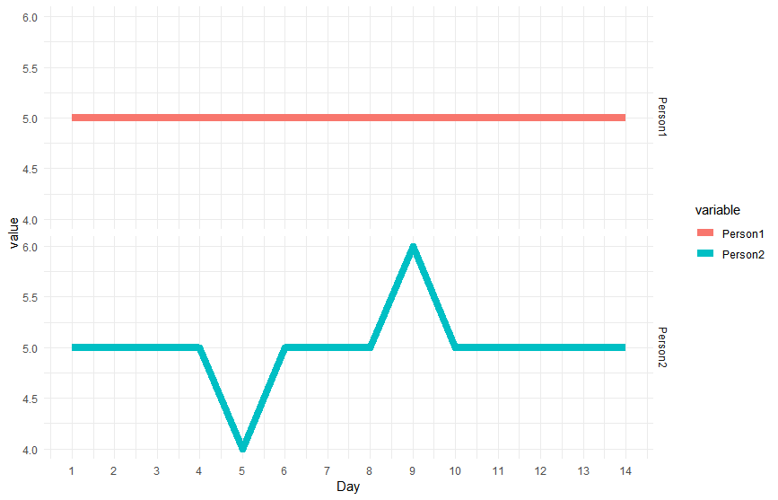

# Acknowledgements

Nelson A. Roque was supported by National Institute on Aging Grant T32 AG049676 to The Pennsylvania State University.

We thank Github user `@blue-yonder`, and other contributors, for creating tsfresh (https://github.com/blue-yonder/tsfresh) and inspiring `tsfeaturex`. We would like to acknowledge and thank Github user `@stas-g`, for code on finding peaks (stas-g (2017)), and Dr. Nilam Ram for code on calculating probability of acute change (PAC).

We gratefully acknowledge contributions from Dr. Nilam Ram, Dr. Anthony Ong, Dr. Martin Sliwinski, and the Sliwinski lab throughout the early development process.

# References

blue-yonder. 2016a. “Allow Nan or None Values to Be Passed in, and Silently Ignored.” *GitHub Repository*. https://github.com/blue-yonder/tsfresh/issues/90; GitHub.

———. 2016b. “Tsfresh.” *GitHub Repository*. https://github.com/blue-yonder/tsfresh; GitHub.

Christ, Maximilian, Nils Braun, Julius Neuffer, and Andreas W Kempa-Liehr. 2018. “Time Series Feature Extraction on Basis of Scalable Hypothesis Tests (Tsfresh–a Python Package).” *Neurocomputing* 307. Elsevier: 72–77.

IBM Marketing Cloud. 2017. “10 Key Marketing Trends for 2017 and Ideas for Exceeding Customer Expectations.” IBM. https://www.ibm.com/downloads/cas/XKBEABLN.

Jahng, Seungmin, Phillip K. Wood, and Timothy J. Trull. 2008. “Analysis of affective instability in ecological momentary assessment: Indices using successive difference and group comparison via multilevel modeling.” *Psychological Methods* 13 (4): 354–75. doi:10.1037/a0014173.

Roque, Nelson. 2019. “Tsfeaturex.” Zenodo. doi:10.5281/zenodo.2574990.

stas-g. 2017. “FindPeaks.” *GitHub Repository*. https://github.com/stas-g/findPeaks; GitHub.